# Carregamento e preparação dos dados

```r
library(ggplot2)
library(dplyr)
library(gridExtra)
library(corrplot)
library(FactoMineR)
library(factoextra)
```

## Carregar os dados e visualização das primeiras linhas

```r
X2024 <- read.csv("D:/Usuarios/Admin/Downloads/2024.csv")
X2023 <- read.csv("D:/Usuarios/Admin/Downloads/2023.csv")
X2022 <- read.csv("D:/Usuarios/Admin/Downloads/2022.csv")
dados <- rbind(X2024, X2023, X2022)
head(dados)
```

```
##         data cod_vendedor                  cod_loja cod_transacao quantidade
## 1 2024-05-31          239         SP Capital Sul_18    0003c03474          7
## 2 2024-05-30          145                     RJ_31    000a0cb29f          5
## 3 2024-05-29          909 SP Capital Leste/Oeste_58    000a114a81          4
## 4 2024-05-29          909 SP Capital Leste/Oeste_58    000a114a81          8
## 5 2024-05-30          240                     SC_30    000a8aa0be          1
## 6 2024-05-29          697                     RS_16    000b7a8be7          2
##       cod_prod     preco
## 1 711147737185 370.27306
## 2 217674649903 176.30504
## 3 761888570923 181.88331
## 4 851717490895 356.34130
## 5 120545844331  29.69201
## 6 721972741868  96.51065
```

## Verificação da estrutura dos dados

```r
str(dados)
```

```
## 'data.frame':    17360703 obs. of  7 variables:
##  $ data         : chr  "2024-05-31" "2024-05-30" "2024-05-29" "2024-05-29" ...
##  $ cod_vendedor : int  239 145 909 909 240 697 697 788 123 123 ...
##  $ cod_loja     : chr  "SP Capital Sul_18" "RJ_31" "SP Capital Leste/Oeste_58" "SP Capital Leste/Oeste_58" ...
##  $ cod_transacao: chr  "0003c03474" "000a0cb29f" "000a114a81" "000a114a81" ...
##  $ quantidade   : int  7 5 4 8 1 2 1 4 8 7 ...
##  $ cod_prod     : num  7.11e+11 2.18e+11 7.62e+11 8.52e+11 1.21e+11 ...
##  $ preco        : num  370.3 176.3 181.9 356.3 29.7 ...
```

## Resumo estatistico

```r
summary(dados)
```

```
##      data            cod_vendedor      cod_loja         cod_transacao
##  Length:17360703    Min.   :   1.0   Length:17360703    Length:17360703
##  Class :character   1st Qu.: 252.0   Class :character   Class :character
##  Mode  :character   Median : 493.0   Mode  :character   Mode  :character
##                     Mean   : 499.3
##                     3rd Qu.: 757.0
##                     Max.   :1000.0
##    quantidade       cod_prod             preco
##  Min.   :1.000   Min.   :6.587e+09   Min.   :  11.33
##  1st Qu.:2.000   1st Qu.:2.562e+11   1st Qu.: 104.40
##  Median :4.000   Median :5.372e+11   Median : 204.98
##  Mean   :3.652   Mean   :5.177e+11   Mean   : 363.97
##  3rd Qu.:5.000   3rd Qu.:7.870e+11   3rd Qu.: 394.22
##  Max.   :8.000   Max.   :9.970e+11   Max.   :4303.16
```

## Descrição das variaveis

- data: É a data que o vendedor realizou uma venda
- cod_prod: É o codigo do produto vendido pelo vendedor
- cod_vendedor: É a indentificação do vendedor
- preco: É o preco do produto multiplicado pela quantidade vendida
- cod_loja: É o codigo indentificador da loja que foi vendido os produtos
- cod_transacao: É o codigo indentificador da transação
- quantidade: É a quantidade de produtos vendido pelo vendedor

# Analise Univariada

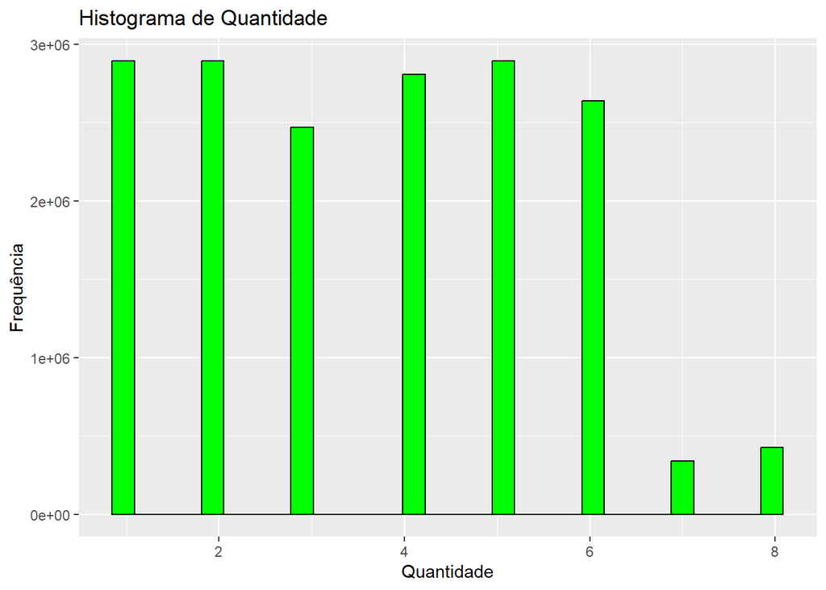

```r
# Histograma para a quantidade
ggplot(dados, aes(x = quantidade)) +
  geom_histogram(bins = 30, fill = "green", color = "black") +
  labs(title = "Histograma de Quantidade", x = "Quantidade", y = "Frequência")
```

## Outliers

```r
# Cálculo dos quantis e do IQR para preco
quantile_preco <- quantile(dados$preco, probs = c(0.25, 0.75))
IQR_preco <- quantile_preco[2] - quantile_preco[1]

# Cálculo dos quantis e do IQR para quantidade
quantile_quantidade <- quantile(dados$quantidade, probs = c(0.25, 0.75))
IQR_quantidade <- quantile_quantidade[2] - quantile_quantidade[1]

# Ajustando os limites inferiores para não permitir valores negativos
lower_bound_preco <- max(0, quantile_preco[1] - 1.5 * IQR_preco)
lower_bound_quantidade <- max(0, quantile_quantidade[1] - 1.5 * IQR_quantidade)

# Limites superiores para identificação de outliers
upper_bound_preco <- quantile_preco[2] + 1.5 * IQR_preco
upper_bound_quantidade <- quantile_quantidade[2] + 1.5 * IQR_quantidade

# Identificando outliers considerando os limites ajustados para preco
outliers_preco_count <- nrow(dados %>%
  filter(preco > upper_bound_preco))

# Identificando outliers considerando os limites ajustados para quantidade
outliers_quantidade_count <- nrow(dados %>%
  filter(quantidade > upper_bound_quantidade))

# Visualização dos resultados
cat("Numero de Outliers em Preco:", outliers_preco_count, "\n")
```

```
## Numero de Outliers em Preco: 1683725
```

```r
cat("Numero de Outliers em Quantidade:", outliers_quantidade_count, "\n")
```

```
## Numero de Outliers em Quantidade: 0
```

```r
print("Ajustes nos Limiares:")
```

```
## [1] "Ajustes nos Limiares:"
```

```r
print(paste("Limite Inferior Preco:", lower_bound_preco))
```

```
## [1] "Limite Inferior Preco: 0"
```

```r
print(paste("Limite Superior Preco:", upper_bound_preco))
```

```
## [1] "Limite Superior Preco: 828.952502160078"
```

```r
print(paste("Limite Inferior Quantidade:", lower_bound_quantidade))
```

```
## [1] "Limite Inferior Quantidade: 0"
```

```r
print(paste("Limite Superior Quantidade:", upper_bound_quantidade))
```

```
## [1] "Limite Superior Quantidade: 9.5"
```

Com o calculo do interquartil foram encontrados outliers apenas nos dados de preco sendo 1.683.725 outliers.

# Analise Bivariada

## Gráfico de dispersão

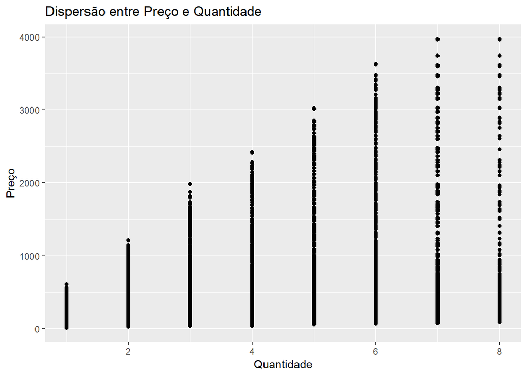

```r
# Gráfico de dispersão entre preço e quantidade
ggplot(X2024, aes(x = quantidade, y = preco)) +
  geom_point(alpha = 0.5) +
  ggtitle("Dispersão entre Preço e Quantidade") +
  xlab("Quantidade") +
  ylab("Preço")
```

## Matriz de correlação

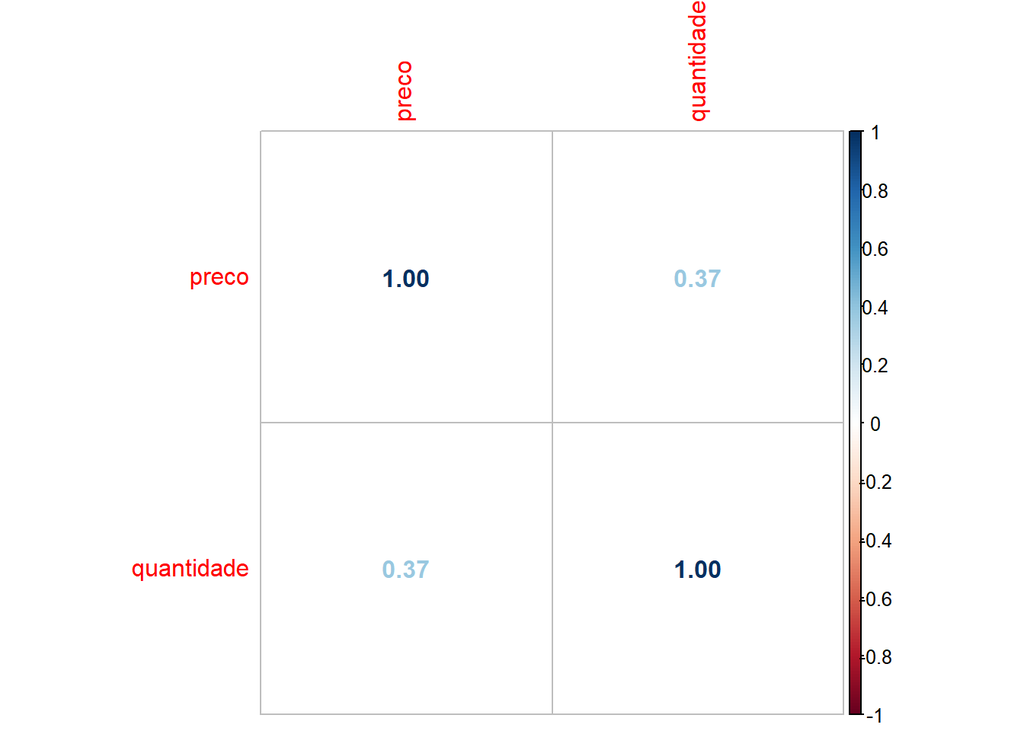

```r
numeric_data <- dados[, c("preco", "quantidade")]

# Calculando a matriz de correlação
cor_matrix <- cor(numeric_data, use = "pairwise.complete.obs")

# Método Number
corrplot(cor_matrix, method = "number")
```

# Analise Multivariada

## Análise de Componentes Principais (PCA)

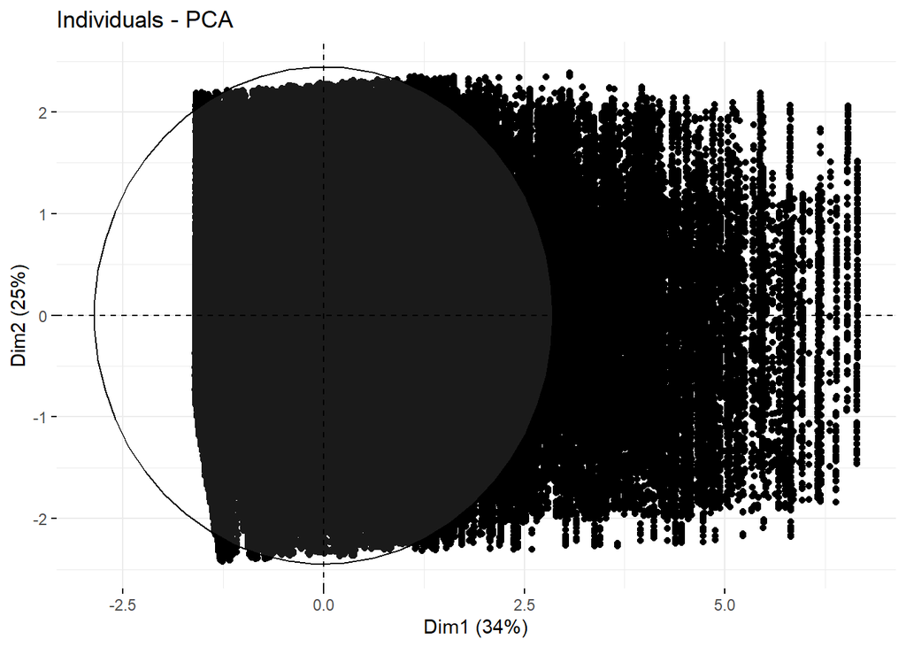

```r
dados2024 <-   X2024
dados_num <- dados2024[, sapply(dados2024, is.numeric)]

# Executando PCA
res.pca <- PCA(dados_num, graph = FALSE)

# Visualizando os resultados da PCA sem a coluna categoria
fviz_pca_ind(res.pca,
             geom.ind = "point",
             addEllipses = TRUE,
             legend.title = "Observations")
```

```r
# Extrai os loadings dos componentes principais
loadings <- res.pca$var$coord
print(loadings)
```

```
##                     Dim.1       Dim.2        Dim.3        Dim.4
## cod_vendedor  0.003473147 0.888231648 -0.459368940 -0.003557121
## quantidade    0.818338449 0.052494406  0.112714003 -0.561125720
## cod_prod     -0.108699360 0.456647003  0.880510310  0.066026942
## preco         0.824706838 0.004358018  0.006145409  0.565510277
```

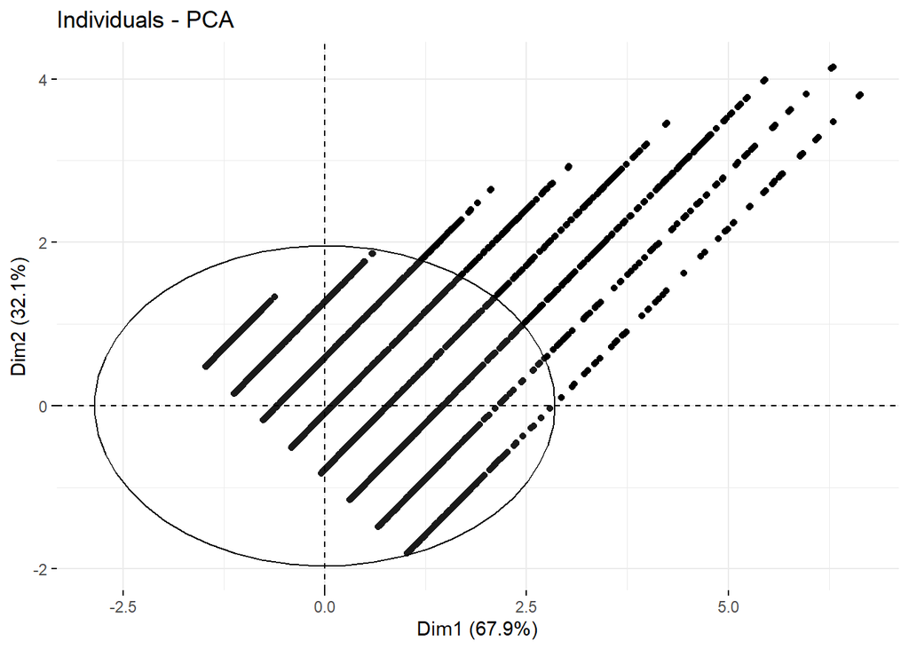

```r
dados_num1 <- dados_num[, !colnames(dados_num) %in% c("cod_vendedor", "cod_prod")]
res.pca1 <- PCA(dados_num1, graph = FALSE)

fviz_pca_ind(res.pca1,
             geom.ind = "point",
             addEllipses = TRUE,
             legend.title = "Observations")
```

```r
loadings <- res.pca1$var$coord
print(loadings)
```

```
##                Dim.1      Dim.2
## quantidade 0.8241627 -0.5663531
## preco      0.8241627  0.5663531
```

## Interpretação dos componentes principais

### Primeira Análise PCA

A primeira análise incluiu todas as variáveis numéricas, incluindo os códigos identificadores (cod_vendedor e cod_prod). Os loadings principais, que medem a contribuição de cada variável para os componentes principais, foram:

Dimensão 1 (34% da variância explicada): preco e quantidade têm loadings altos e positivos, indicando que essas duas variáveis são as mais influentes nesta dimensão. Dimensão 2 (25% da variância explicada): cod_vendedor tem um loading muito alto, significando que essa variável tem um forte impacto nesta dimensão. Isto pode ser devido à variabilidade entre vendedores. Dimensões 3 e 4: Menores contribuições de cod_prod e outras variáveis.

A análise revela que enquanto preco e quantidade são importantes na primeira dimensão, os identificadores como cod_vendedor e cod_prod influenciam significativamente as outras dimensões. Isso pode ser problemático, pois identificadores não devem idealmente influenciar a análise. Eles não representam variáveis de interesse mas sim categorias, o que distorce interpretações.

### Segunda Análise PCA

Na segunda análise, foi excluido os identificadores, deixando apenas quantidade e preco. Os resultados foram:

Dimensão 1 (67.9% da variância explicada): Ambas quantidade e preco têm loadings idênticos e positivos, sugerindo que eles variam juntos e contribuem igualmente para esta dimensão. Dimensão 2 (32.1% da variância explicada): Os sinais opostos de quantidade e preco nesta dimensão indicam que eles têm uma relação inversa quando considerados sob esta perspectiva.

Esta análise sugere uma estrutura mais simplificada e clara, onde as duas variáveis remanescentes explicam totalmente a variância nos dados, sem a confusão introduzida pelos identificadores.

### Interpretação e Discussão:

- Influência dos Identificadores: A exclusão dos códigos identificadores na segunda análise resultou em uma explicação mais clara e mais útil da variância nos dados. Isso sugere que incluir identificadores pode não ser ideal para análises como PCA, onde o interesse está em entender relações sublinhantes entre variáveis de interesse.
- Relações entre Variáveis: Na primeira análise, a dimensão que captura a maior parte da variância estava associada ao preco e quantidade, sugerindo que estas variáveis têm um papel fundamental nos seus dados. Na segunda análise, essas duas variáveis também explicaram toda a variância, destacando sua importância.
- Decisões para Análise Futura: Dependendo do objetivo com a análise PCA, pode-se continuar explorando sem os identificadores ou considerar outras transformações dos dados para melhor capturar as relações de interesse.

# Conslusão e discusão

## Sumario das descobertas

Na analise univariada ao aplicar o histograma é possivel perceber a frenquencia com que essas quantidades são vendidas e podemos perceber a partir dela que temos uma menor frequencia de vendas de sete ou mais produtos, tendo uma frenquencia muito mais relevante na venda de até seis produtos.

Na analise bivariada usando da matriz de correlação e do grafico de dispersão podemos perceber mais sobre a correlação preco/quantidade, no grafico de dispersão parece termos uma correlação grande entre essas variaveis, mas ao ver a matriz de correlação percebemos que a correlação entre essas variaveis é de 0.37 o que não é algo tão alto.

Na analise multivariada fizemos duas analises uma com os dados preco, quantidade, cod_vendedor e cod_prod e outra apenas com preco e quantidade das quais obtivemos resultados bem diferentes, é descorrido mais sobre o assunto na seção “Interpretação dos componentes principais”

## Discussão sobre limitações e possiveis melhorias

Algo que me limitou foi o poder computacional que eu tinha a disposição, por conta disso não consegui analisar todos os datasets disponiveis, outra limitação foi a falta de conhecimento sobre analises de dados, que é um assunto que entendo apenas o basico.

De possiveis melhorias acredito que na analise multivariuada seria possivel fazer um algum tratamento dos dados de cod_prod e cod_vendedor para serem variaveis mais acertivas nessa analise.